# Paper 3 possibilities

# Lateral instability:

Temporal trend through low/high feed periods:

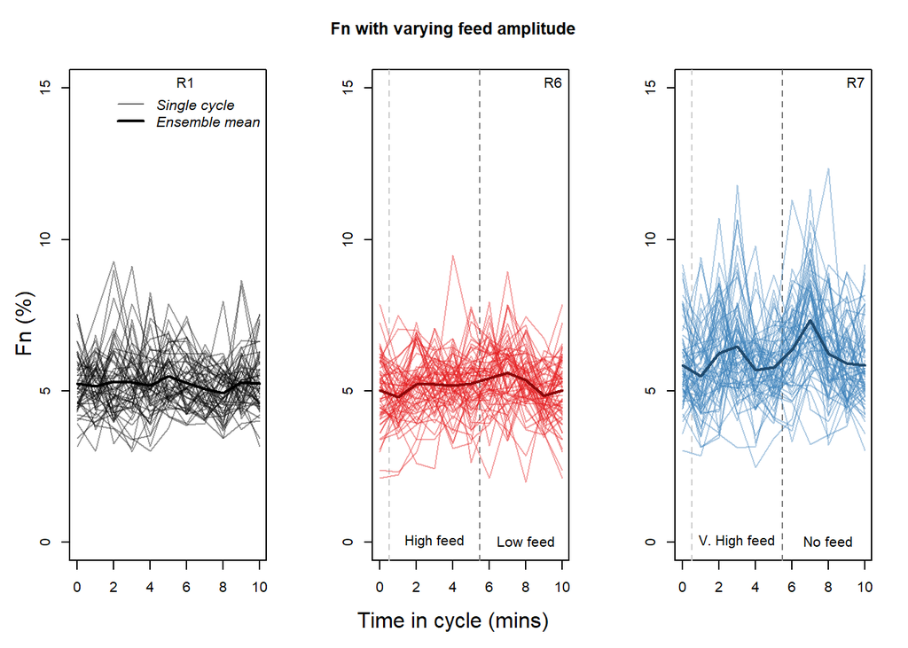

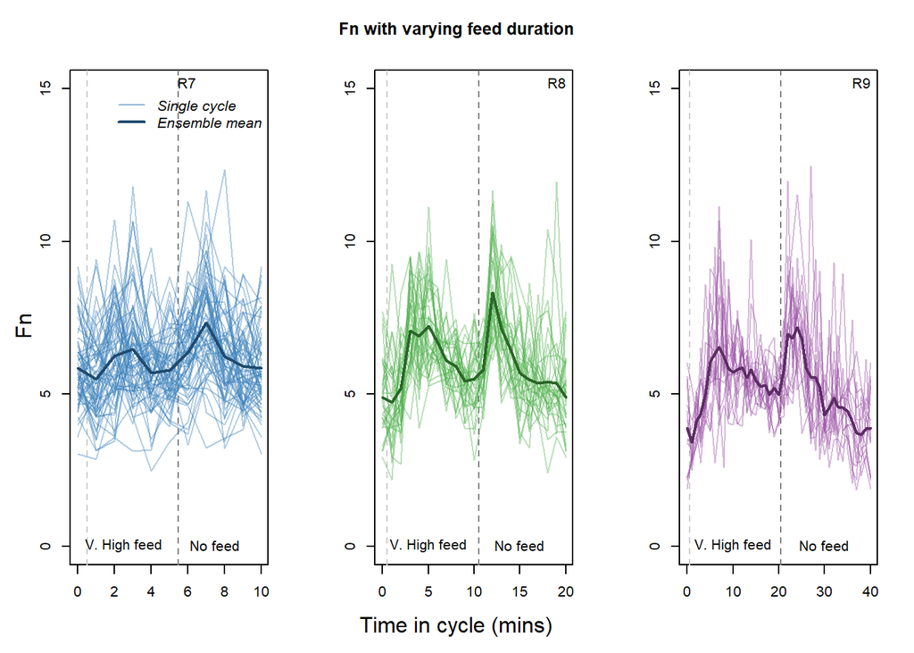

# Channel pattern variability

Binary where channel = 1, “dry” = 0.

### Number of channels

Plot through time (cycles superimposed)

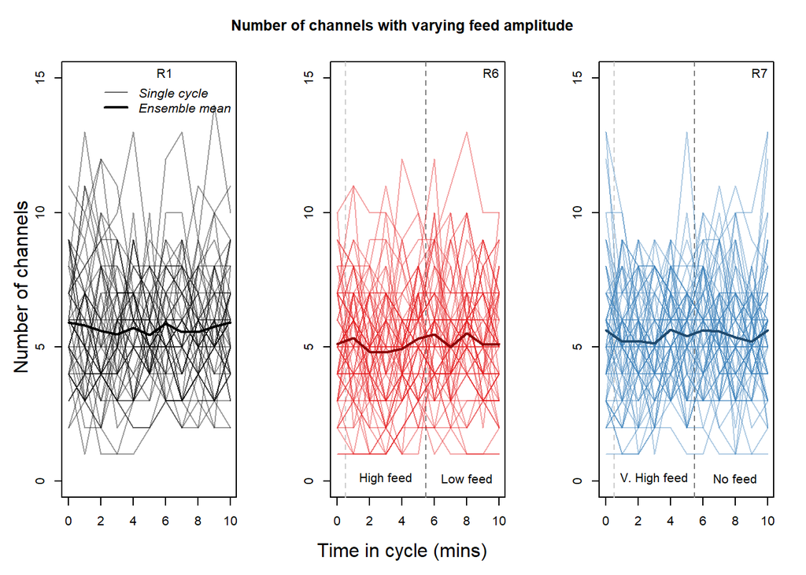

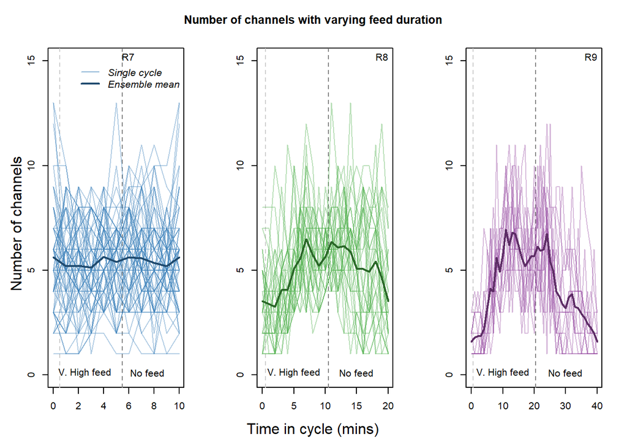

### Active Sector

Plot through time (cycles superimposed)

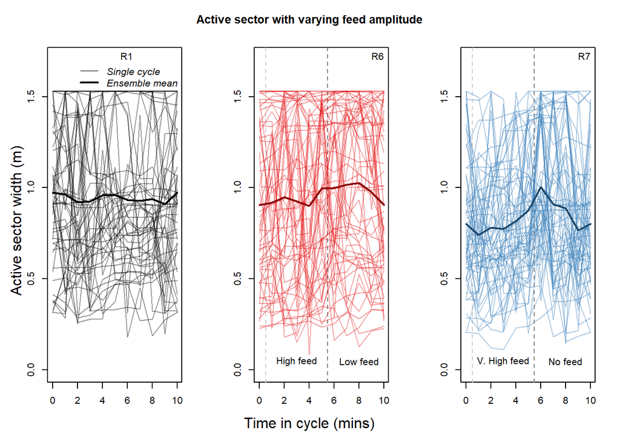

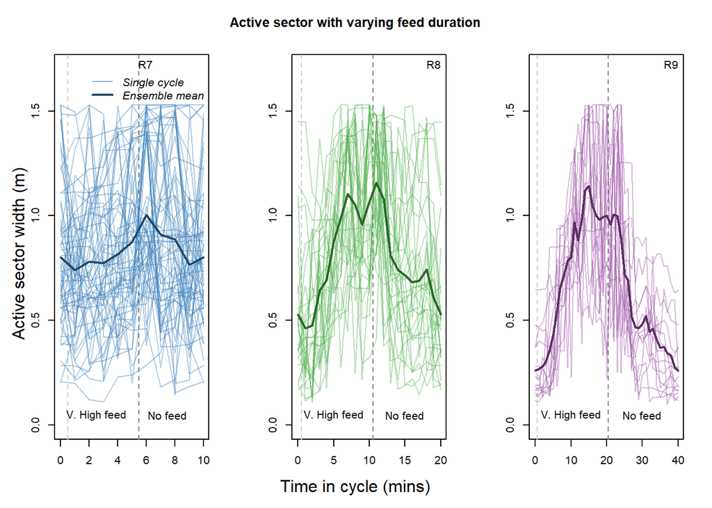

### Wet fraction

Plot through time (cycles superimposed)

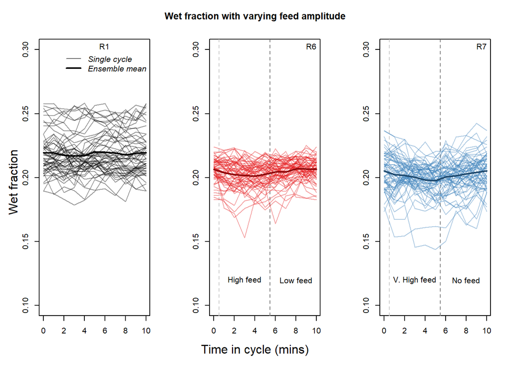

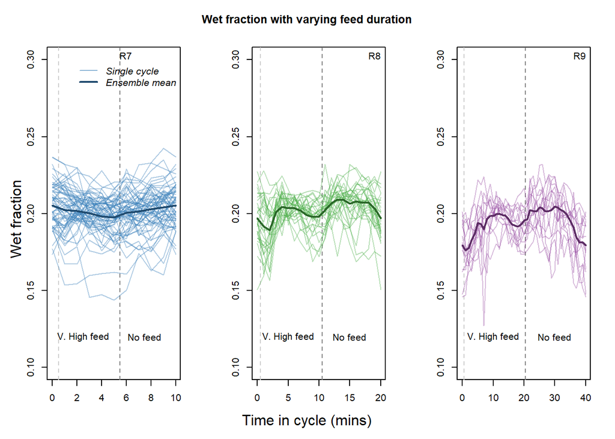

# Topographic change

### Erosion, deposition and M (morphologic change)

Outliers removed (agg or deg above a certain threshold).

How did agg/deg/M rates change throughout cycle?

Deposition:

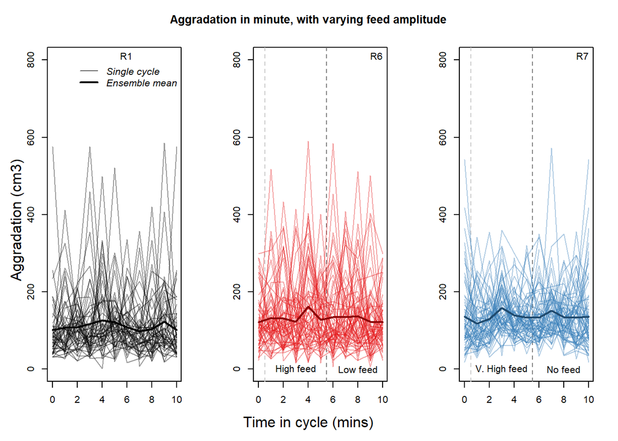

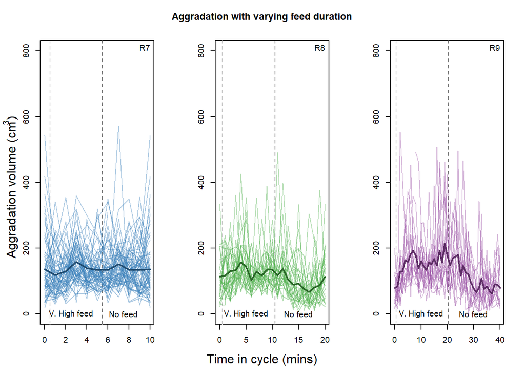

Erosion:

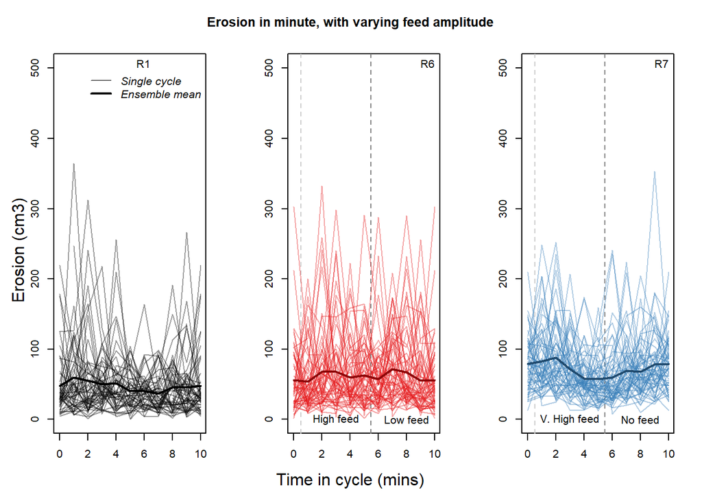

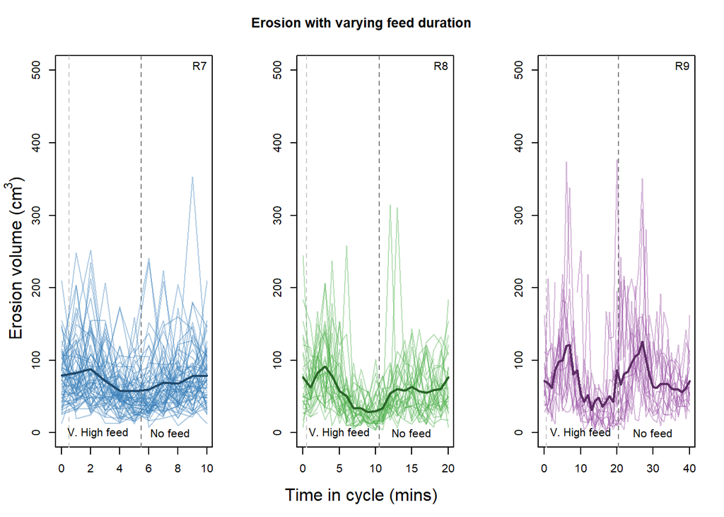

Gross Morphologic Change (M = |deg| + agg) - irons out the nuances, esp for run 9.

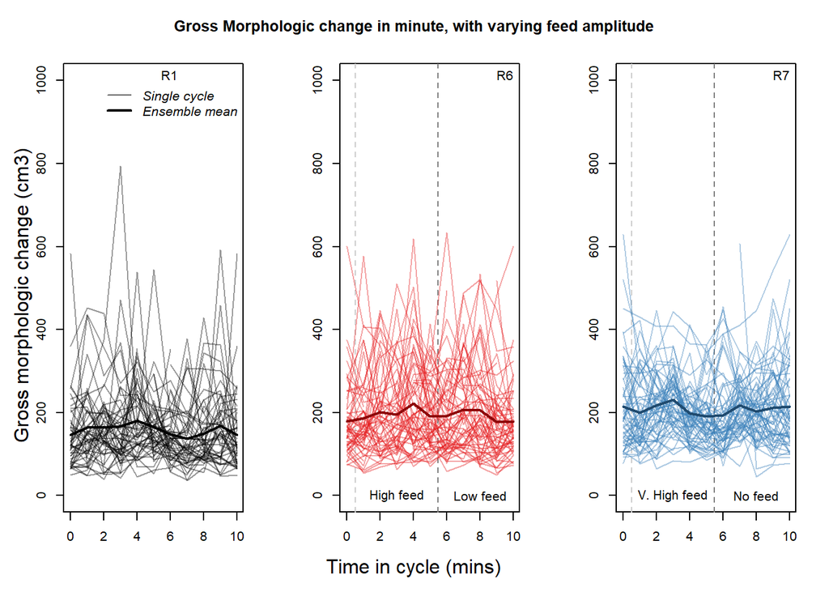

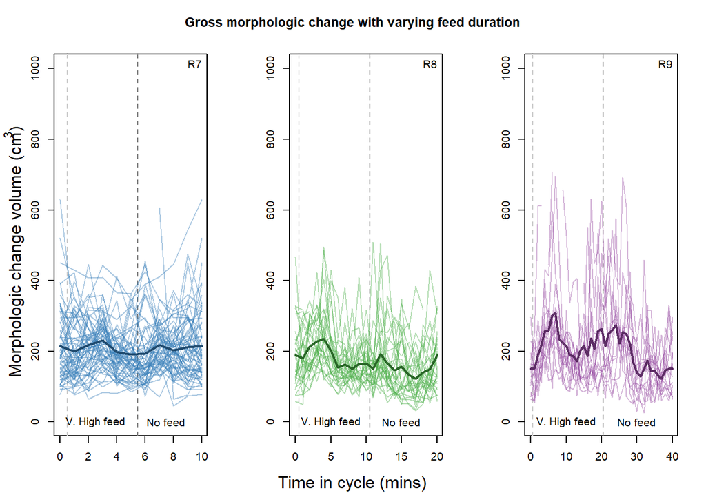

## Spatial patterns of erosion/deposition

Mean of all 1-min DoDs, for high and low feed respectively:

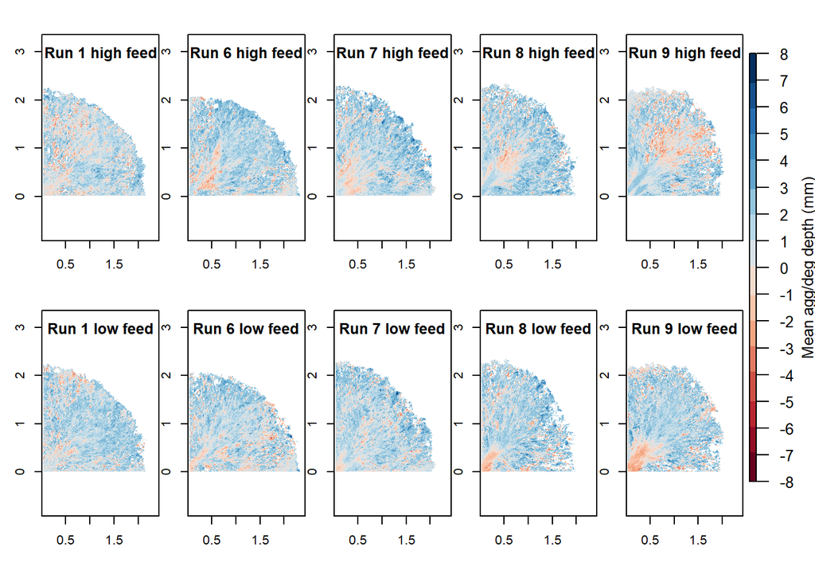

# To do:

Figure tidying:

- 4-run comparison slope evolution plot:
  - add run 1
  - tidy plot widths (should be same scale, diff widths)
  - colour with time? (darker through time)
- same for Fn time in cycle plot
- same for basically all other plots!

DoDs:

- Spatial patterns revealed through
  - PCA? Need to replace all NAs with 0 first…

Interrelations:

- When does/doesn’t agg/deg correlate with Fn? I.e. is correlation stronger/weaker in feed / no feed periods?